# DSS Capstone Milestone: Exploratory Analysis

This report is prepared for the Coursera Data Science Specialization Capstone project. Ultimately, I want to build a machine learning model to predict the next word based on its previous one, two or three words in English. Before modeling, it is beneficial to take a big picture on the data input I am using.

## I. Loading Data

There are three [files](https://d396qusza40orc.cloudfront.net/dsscapstone/dataset/Coursera-SwiftKey.zip) storing US blogs, news and twitter messages written in English. For convenience, I downloaded them and will load them from local.

```r
con <- file('en_US.blogs.txt', 'rb')
blogs <- readLines(con)
close(con)
con <- file('en_US.news.txt', 'rb')
news <- readLines(con)
close(con)
con <- file('en_US.twitter.txt', 'rb')
twitter <- readLines(con)
close(con)
```

## II. Basic Statistics

The following code summarizes the three datasets by counting their lines, characters in words, words and checking the average numbers of characters per word and words per line.

```r
library(stringi)
b0 <- stri_stats_general(blogs)
b1 <- stri_stats_latex(blogs)
blog_stat <- as.integer(c(b0[1],b1[c(1,4)],b1[1]/b1[4],b1[4]/b0[1]))
n0 <- stri_stats_general(news)
n1 <- stri_stats_latex(news)
news_stat <- as.integer(c(n0[1],n1[c(1,4)],n1[1]/n1[4],n1[4]/n0[1]))
t0 <- stri_stats_general(twitter)
t1 <- stri_stats_latex(twitter)
twitter_stat <- as.integer(c(t0[1],t1[c(1,4)],t1[1]/t1[4],t1[4]/t0[1]))
all_stat <- rbind(blog_stat, news_stat, twitter_stat)
colnames(all_stat) <- c('Lines', 'CharsInWords', 'Words', 'CharsPerWord', 'WordsPerLine')
all_stat
```

```
##                Lines CharsInWords    Words CharsPerWord WordsPerLine
## blog_stat     899288    163325412 37865888            4           42
## news_stat    1010242    162566126 34678691            4           34
## twitter_stat 2360148    125769312 30578891            4           12
```

As the result, all three datasets have similar word length, although blogs and news have longer lines.

## III. Sampling, Cleanning and Tokenizing

Due to the large size of the datasets, I will sample 1% of the total, convert them into corpora, clean up the corpora and combine them. Here I will not focus on the difference between the three datasets but on what happens after stop words are removed.

```r
library(tm)
library(RWeka)
set.seed(1)
sample.corpus <- function(x) {
  sample_len <- length(x)
  result_corpus <- Corpus(VectorSource(x[sample(1:sample_len, sample_len/100, replace=FALSE)]))
  return(result_corpus)
}
bcorpus <- sample.corpus(blogs)
ncorpus <- sample.corpus(news)
tcorpus <- sample.corpus(twitter)
total_corpus <- c(bcorpus, ncorpus, tcorpus)

total_corpus <- tm_map(total_corpus, content_transformer(function(x) iconv(x, from="latin1", to="ASCII", sub="")))
#You've got to have the above line to remove non-ASCII chars, otherwise 'tolower' will throw an error; curiously this only happens in knitr but not in the console
total_corpus <- tm_map(total_corpus, content_transformer(tolower))
total_corpus <- tm_map(total_corpus, removePunctuation)
total_corpus <- tm_map(total_corpus, removeNumbers)
total_corpus <- tm_map(total_corpus, stripWhitespace)
trimmed_corpus <- tm_map(total_corpus, removeWords, stopwords('english'))
```

So now I have two corpora (total and trimmed) to work with. Next I will tokenize them into one-, two- and three-gram matices.

```r
UnigramTokenizer <- function(x) NGramTokenizer(x, Weka_control(min = 1, max = 1))
BigramTokenizer  <- function(x) NGramTokenizer(x, Weka_control(min = 2, max = 2))
TrigramTokenizer <- function(x) NGramTokenizer(x, Weka_control(min = 3, max = 3))
total_uni <- TermDocumentMatrix(total_corpus, control=list(tokenize = UnigramTokenizer))
total_bi <- TermDocumentMatrix(total_corpus, control=list(tokenize = BigramTokenizer))
total_tri <- TermDocumentMatrix(total_corpus, control=list(tokenize = TrigramTokenizer))
trimmed_uni <- TermDocumentMatrix(trimmed_corpus, control=list(tokenize = UnigramTokenizer))
trimmed_bi <- TermDocumentMatrix(trimmed_corpus, control=list(tokenize = BigramTokenizer))
trimmed_tri <- TermDocumentMatrix(trimmed_corpus, control=list(tokenize = TrigramTokenizer))
```

So the top counted grams in each corpus are as follows:

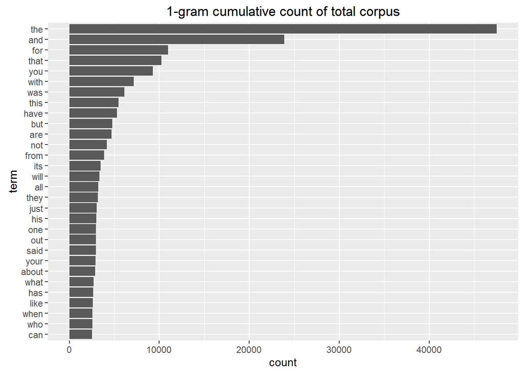

```r
library(slam)
library(ggplot2)
bartop <- function(x, top, gram, corpustype) {
  #x is the matrix, top is the number of top grams, gram is number of gram and corpustype is 'total' or 'trimmed'
  sum_count <- head(sort(row_sums(x), decreasing=TRUE),top)
  df <- data.frame(term=names(sum_count), count=sum_count)
  df$term <- reorder(df$term, df$count)
  ggplot(data=df, aes(x=term, y=count)) + geom_bar(stat='identity') + coord_flip() + ggtitle(paste(gram, '-gram cumulative count of ', corpustype, ' corpus', sep=''))
}
bartop(total_uni, 30, 1, 'total')
```

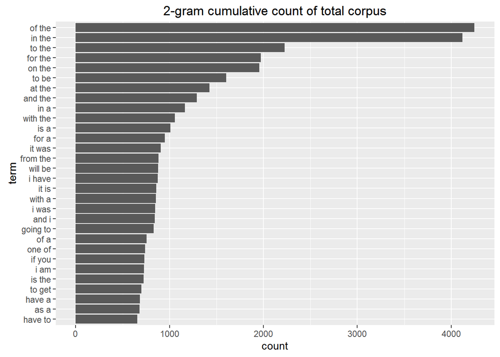

```r
bartop(total_bi, 30, 2, 'total')
```

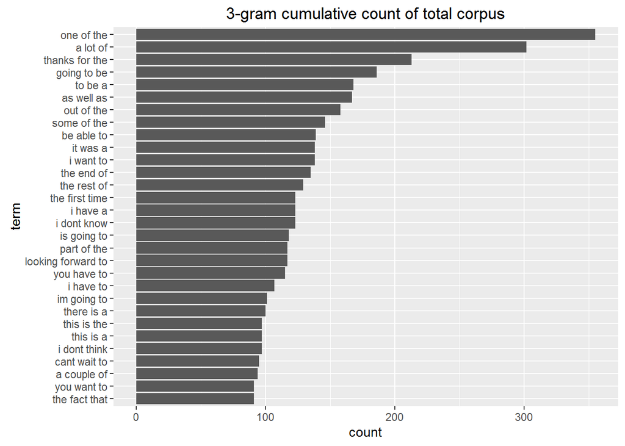

```r
bartop(total_tri, 30, 3, 'total')
```

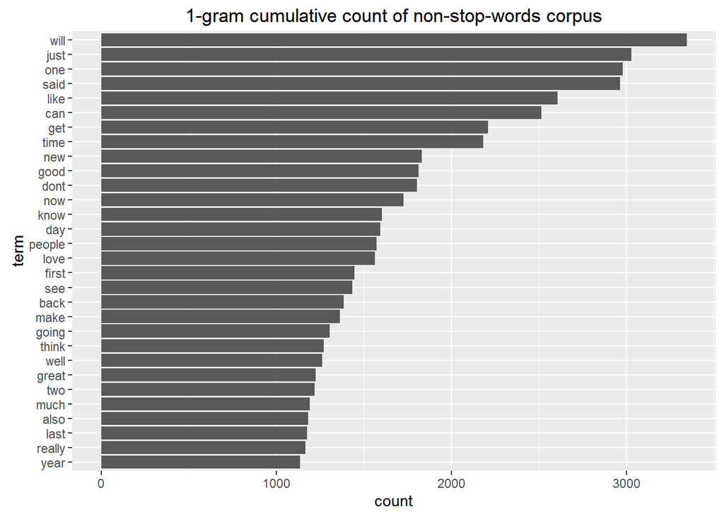

```r
bartop(trimmed_uni, 30, 1, 'non-stop-words')
```

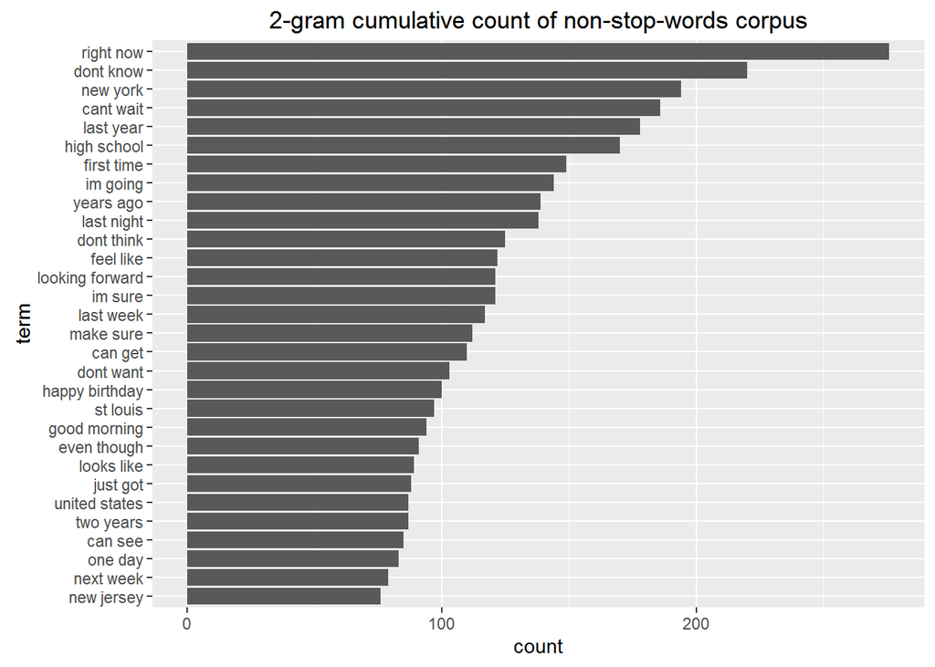

```r
bartop(trimmed_bi, 30, 2, 'non-stop-words')
```

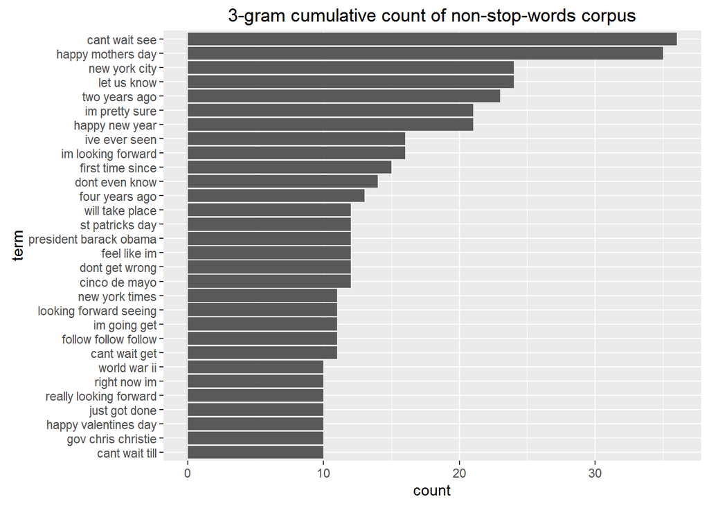

```r
bartop(trimmed_tri, 30, 3, 'non-stop-words')
```

It is not surprising to see high counts of stop words in the total corpus. However, the corpus without stop words does have some interesting patterns.

## IV. Plan

1 Calculate the frequency of grams

2 Use the results to fit an n-gram model

3 Optimize the model

4 Build a shiny app and write a pitch deck